Cargar las librerías `sp` y `raster`.

```r
library(sp)
library(raster)
```

# Vectorial

**Importar**  
Para importar archivos `shapefile`, del paquete `raster`.  
Cargamos los archivos vectoriales de las comunidades autónomas `spain.shp` y los parques naturales y nacionales `AP_spain.shp` de España.

```r
Spain <- raster::shapefile("E:/SEMINARIO_BIOGEOGRAFIA/VECTORIAL/SPAIN/spain.shp")
PA <- shapefile("E:/SEMINARIO_BIOGEOGRAFIA/VECTORIAL/PNAC/AP_spain.shp")
```

**Visualizar**

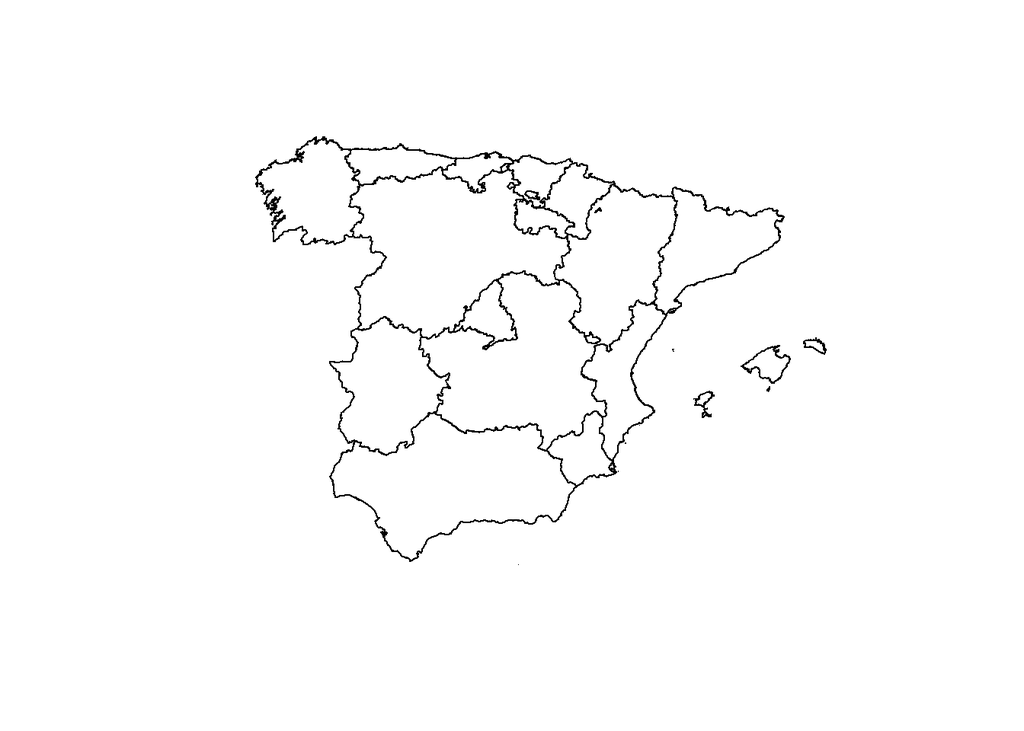

```r
plot(Spain)
```

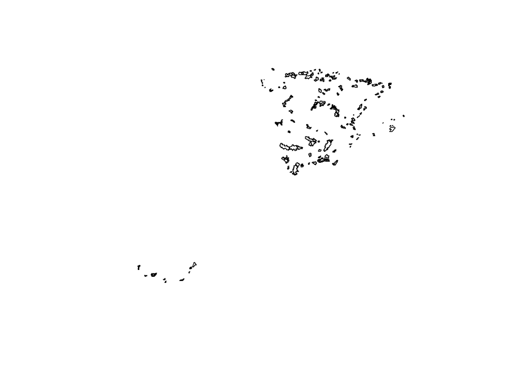

```r
plot(PA)
```

**Proyectar**  
Para conocer el sistema de referencia `proj4string()`.

```r
proj4string(Spain)
```

```
## [1] "+proj=longlat +datum=WGS84 +no_defs"
```

```r
proj4string(PA)
```

```
## [1] "+proj=utm +zone=30 +ellps=GRS80 +towgs84=0,0,0,0,0,0,0 +units=m +no_defs"
```

Para modificar el sistema de referencia `spTransform` se utiliza el código EPSG (https://spatialreference.org/ref/epsg).  
*WGS84 (Lat/Long): 4326*  
*ETRS89/UTM 30N: 25830*

```r
Spain <- spTransform(Spain, CRS("+init=epsg:25830"))
```

Si se quiere utilizar el sistema de referencia de otra capa.  
En lugar de indicar el sistema de referencia, mediante las funciónes `CRS` y `proj4string`, se utiliza el sistema de referencia de otra capa.

```r
Spain <- spTransform(Spain,
                     CRS(proj4string(PA)))
```

**Variables del objeto**  
Para acceder a las variables del objeto se utiliza `@` (`Spain@`) o la función `slotNames`.  
-`data`: Tabla de atributos  
-`polygons`: Coordenadas de todos los vértices de cada poligono  
-`plotOrder`: Orden en el que están los poligonos de la capa  
-`bbox`: Coordenadas del marco más extenso (xmin, ymin, xmax e ymax)  
-`proj4string`: Tipo de proyección de la capa

```r
slotNames(Spain)
```

```
## [1] "data"        "polygons"    "plotOrder"   "bbox"        "proj4string"
```

Para conocer las coordenadas de los extremos de la capa

```r
Spain@bbox
```

```
##          min     max
## x  -14129.47 1126923
## y 3977033.09 4859517
```

**Tabla de atributos**  
Para acceder a la tabla de atributos se utiliza `$`(`Spain@data$NAME`o directamente `Spain$NAME` ).

```r
Spain@data
```

```
##    COUNTRY          NATLEVNAME CODNUT1 CODNUT2                       CCAA
## 0       ES Comunidad autÃ³noma     ES6    ES61                  Andalucia
## 1       ES Comunidad autÃ³noma     ES2    ES24                     Aragon
## 2       ES Comunidad autÃ³noma     ES1    ES12     Principado de Asturias
## 3       ES Comunidad autÃ³noma     ES5    ES53              Illes Balears
## 4       ES Comunidad autÃ³noma     ES1    ES13                  Cantabria
## 5       ES Comunidad autÃ³noma     ES4    ES41            Castilla y Leon
## 6       ES Comunidad autÃ³noma     ES4    ES42         Castilla-La Mancha
## 7       ES Comunidad autÃ³noma     ES5    ES51        CataluÃ±a/Catalunya
## 8       ES Comunidad autÃ³noma     ES5    ES52       Comunitat Valenciana
## 9       ES Comunidad autÃ³noma     ES4    ES43                Extremadura
## 10      ES Comunidad autÃ³noma     ES1    ES11                    Galicia
## 11      ES Comunidad autÃ³noma     ES3    ES30        Comunidad de Madrid
## 12      ES Comunidad autÃ³noma     ES6    ES62          RegiÃ³n de Murcia
## 13      ES Comunidad autÃ³noma     ES2    ES22 Comunidad Foral de Navarra
## 14      ES Comunidad autÃ³noma     ES2    ES21        PaÃs Vasco/Euskadi
## 15      ES Comunidad autÃ³noma     ES2    ES23                   La Rioja
```

```r
Spain$CCAA
```

```
##  [1] "Andalucia"                  "Aragon"
##  [3] "Principado de Asturias"     "Illes Balears"
##  [5] "Cantabria"                  "Castilla y Leon"
##  [7] "Castilla-La Mancha"         "CataluÃ±a/Catalunya"
##  [9] "Comunitat Valenciana"       "Extremadura"
## [11] "Galicia"                    "Comunidad de Madrid"
## [13] "RegiÃ³n de Murcia"          "Comunidad Foral de Navarra"
## [15] "PaÃs Vasco/Euskadi"        "La Rioja"
```

Seleccionar objetos en la tabla de atributos. Seleccionamos la comunidad autónoma de Aragón y los parques nacionales.

```r
Aragon <- Spain[Spain$CCAA == "Aragon", ]
PNAC <- PA[PA$FIGURA == "Parque Nacional", ]
```

**Visualizar varias capas**  
Para visualizar varias capas superpuestas utilizar `add = TRUE`.

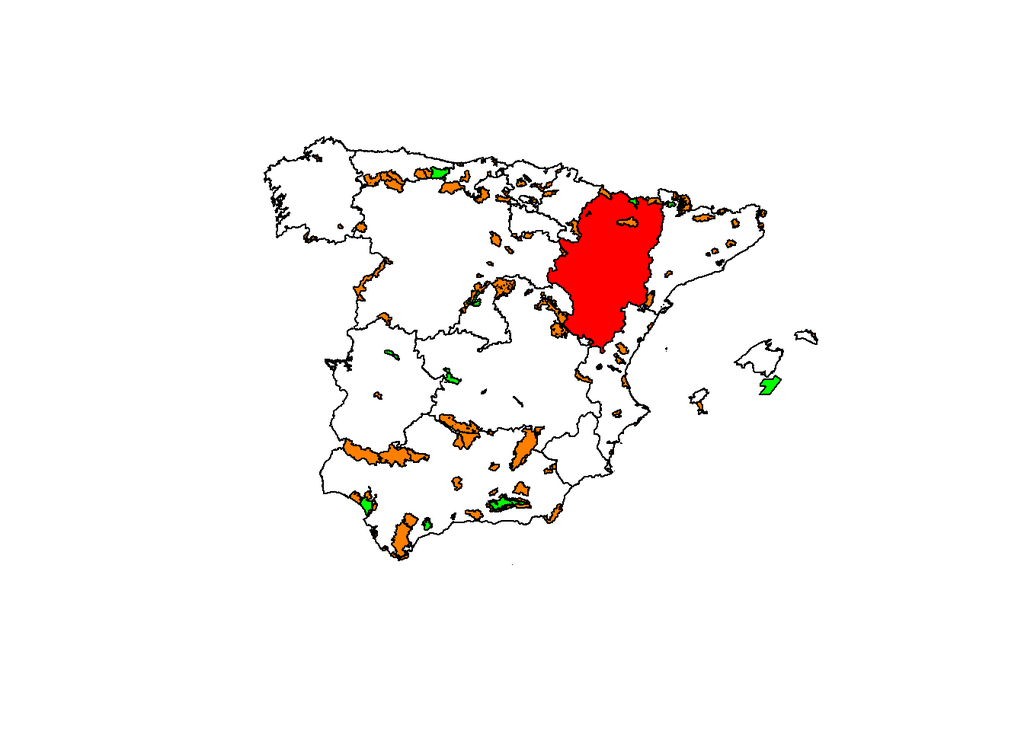

```r
plot(Spain)
plot(Aragon, add = T, col = "red")
plot(PA, add= T, col = "darkorange1")
plot(PNAC, add = T, col = "green")
```

**Cortar capas**  
Para cortar dos archivos vectoriales se puede utilizar la función `intersect` del paquete `raster`.

```r
PA_Aragon <- raster::intersect(Aragon, PA)
```

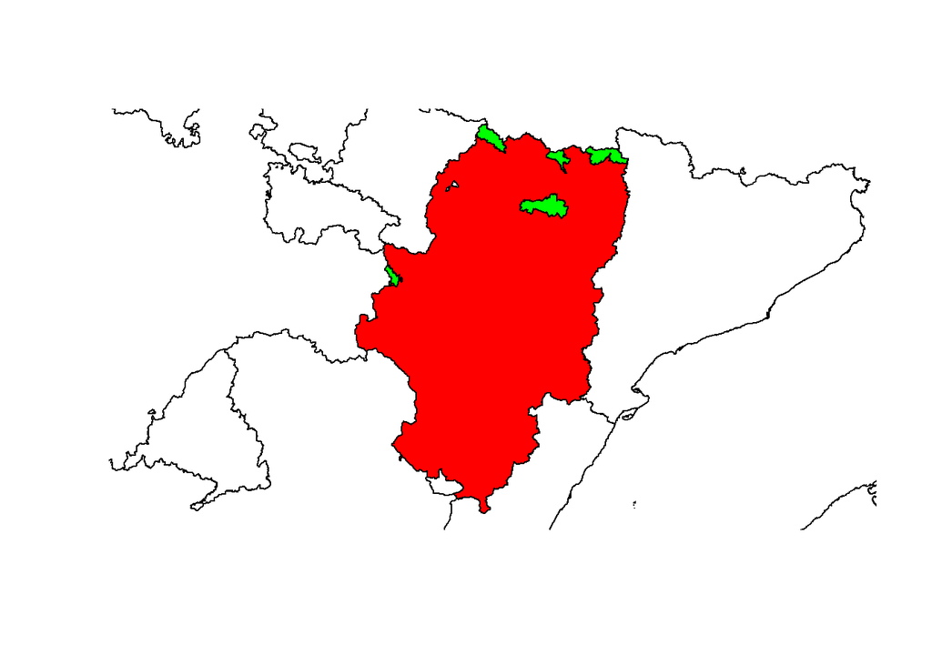

```r
plot(Aragon)
plot(Spain, add = T)
plot(Aragon, add= T, col= "red")
plot(PA_Aragon, add = T, col = "green")
```

**Exportar**  
Para exportar archivos vectoriales utilizar la función `shapefile` del paquete `raster`.

```r
raster::shapefile(Aragon, filename = "E:/SEMINARIO_BIOGEOGRAFIA/RESULTADOS/Aragon.shp", overwrite = TRUE)
```

# Raster

**Importar**  
Para importar archivos `raster` del paquete `raster`.

```r
Temperatura_maxima <- raster("E:/SEMINARIO_BIOGEOGRAFIA/RASTER/SPAIN/TEMPERATURA_MAXIMA.tif")
Temperatura_minima <- raster("E:/SEMINARIO_BIOGEOGRAFIA/RASTER/SPAIN/TEMPERATURA_MINIMA.tif")
```

**Visualizar**

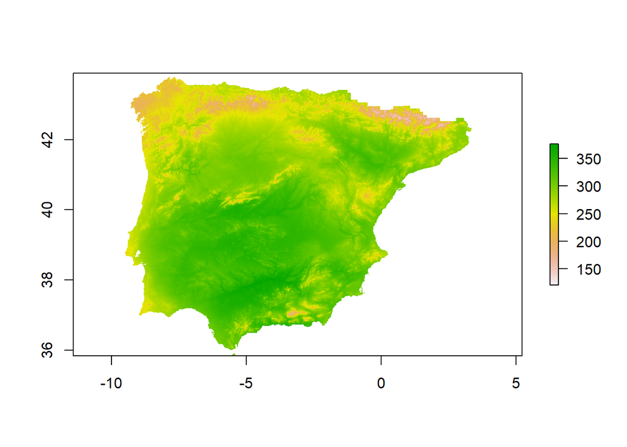

```r
plot(Temperatura_maxima)
```

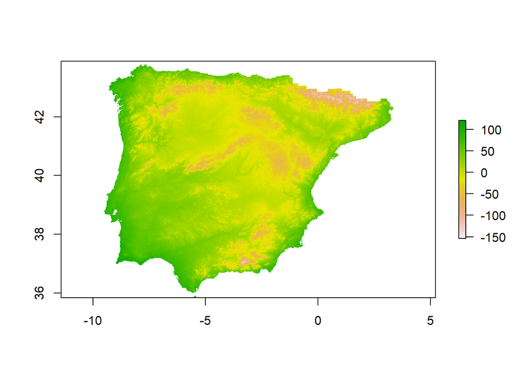

```r
plot(Temperatura_minima)
```

Es posible delimitar los rangos a graficar con el parámetro `zlim`.  
En este caso se visualizan los pixeles que superan los 30ºC (ºC x 10).

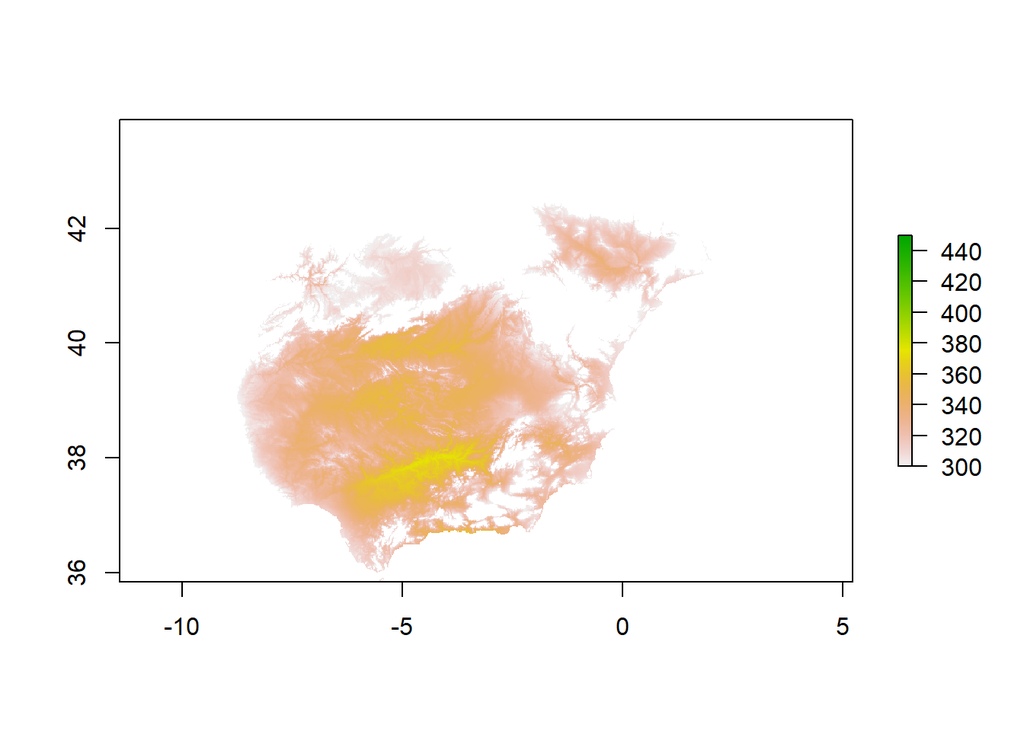

```r
plot(Temperatura_maxima, zlim = c(300, 450))
```

**Unir varios raster en un objeto**  
Esto es muy util para trabajar con varios raster a la vez.

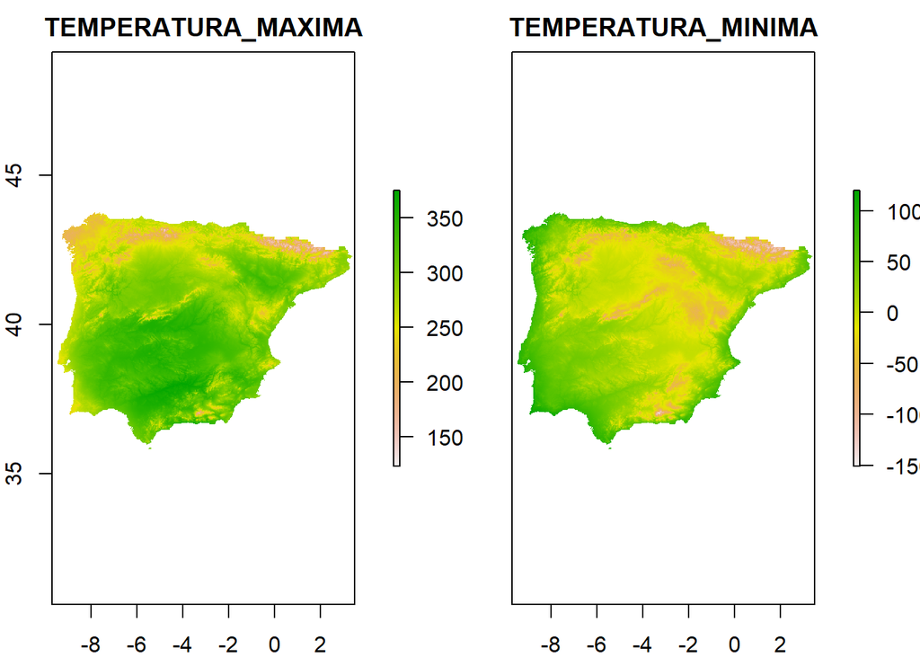

```r
Temperatura <- stack(Temperatura_maxima, Temperatura_minima)
plot(Temperatura)
```

**Proyectar**  
Para conocer el sistema de referencia `projection()`. Esto difiere de los archivos vectoriales.

```r
projection(Temperatura)
```

```
## [1] "+proj=longlat +datum=WGS84 +no_defs"
```

Para modificar el sistema de referencia.

```r
Temperatura <- projectRaster(Temperatura, crs = "+init=epsg:25830")
```

**Algebra raster**  
Las operaciones sobre los raster se ejecutan directamente sobre el objeto.  
En este caso transformamos de ºC x 10 a ºC.

```r
Temperatura$TEMPERATURA_MAXIMA <- Temperatura$TEMPERATURA_MAXIMA / 10
Temperatura$TEMPERATURA_MINIMA <- Temperatura$TEMPERATURA_MINIMA / 10
```

```r
cellStats(Temperatura$TEMPERATURA_MAXIMA, "mean")
```

```
## [1] 29.69703
```

Para ejecutar operaciones entre rasters.  
Se puede actuar directamente sobre los rasters.

```r
Temperatura_media <-  (Temperatura$TEMPERATURA_MAXIMA + Temperatura$TEMPERATURA_MINIMA) / 2
```

Se puede utilizas la función `calc` del paquete `raster`.

```r
Temperatura_media_2 <- calc(Temperatura, mean)
```

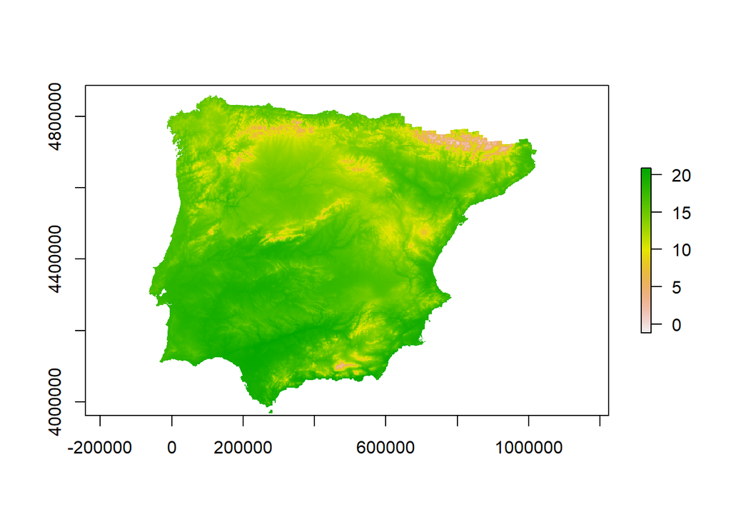

```r
plot(Temperatura_media)
plot(Temperatura_media_2)
```

**Exportar**

```r
writeRaster(Temperatura_media, "E:/SEMINARIO_BIOGEOGRAFIA/RESULTADOS/Temperatura_media.tif")
```

# Operaciones Vector-Raster

**Cortar**  
Cortar capa raster a partir de capa vectorial.  
La función `crop` corta con el extend (bbox) de archivo vectorial.

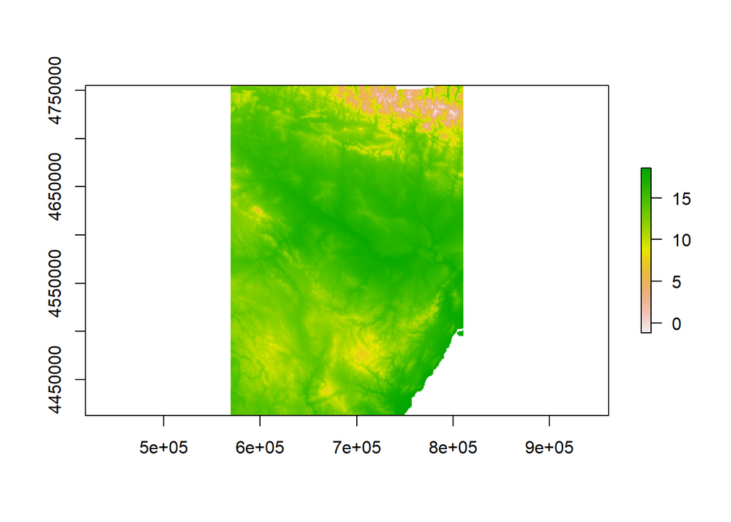

```r
Temperatura_Aragon <- crop(Temperatura_media, Aragon)
plot(Temperatura_Aragon)
```

La función `mask` corta con la geometría del archivo vectorial.

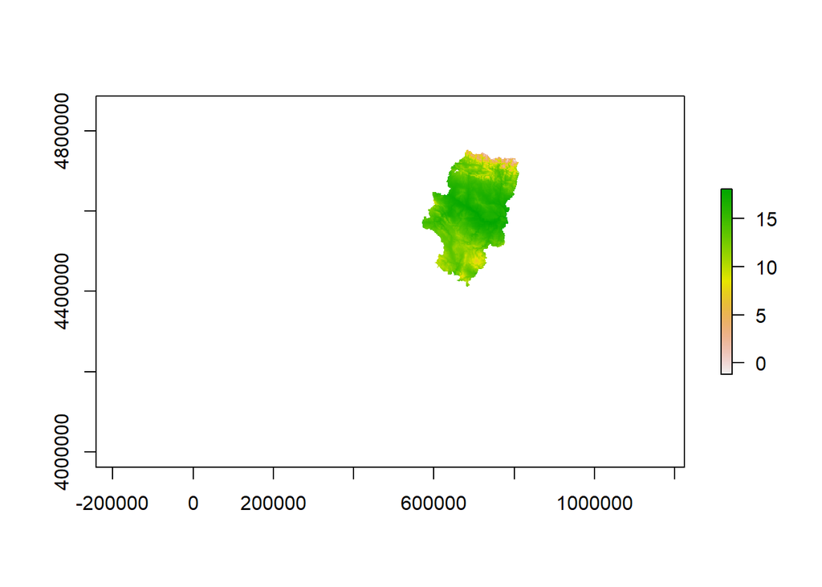

```r
Temperatura_Aragon <- mask(Temperatura_media, Aragon)
plot(Temperatura_Aragon)
```

Es mas rápido cortar primero con `crop`, seguidamente de `mask`.

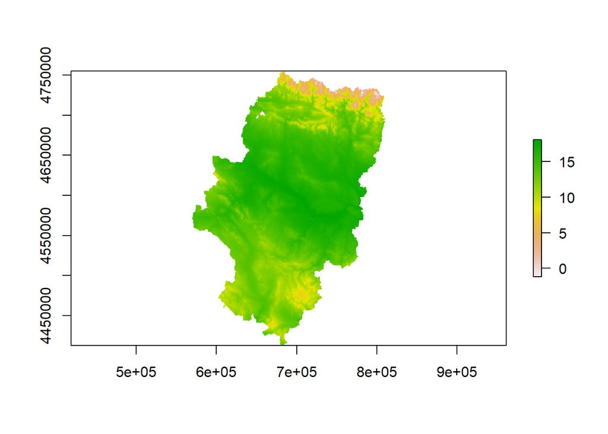

```r
Temperatura_Aragon <- mask(crop(Temperatura_media,
                                Aragon),
                           Aragon)
plot(Temperatura_Aragon)
```

**Extraer información**  
Para extraer la información de un raster utilizando un poligono se utiliza la función `extract`. En este caso extraemos la temperatura de las áreas protegidas de Aragón.

```r
Temperatura_PA <- extract(Temperatura_media, PA_Aragon, fun = mean, df = T)
```

Unimos los nombres de las áreas protegidas `PA_Aragon$NOMBRE` con los resultados `Temperatura_PA`, mediante la funcion `cbind`.

```r
Temperatura_PA <- cbind(PA_Aragon$NOMBRE, Temperatura_PA)
```

```r
Temperatura_PA <- Temperatura_PA[,-2]
colnames(Temperatura_PA) <- c("AREA PROTEGIDA", "TEMPERATURA")
```

```r
Temperatura_PA
```

```
##                    AREA PROTEGIDA TEMPERATURA
## 1          Ordesa y Monte Perdido    5.261702
## 2                 Bardenas Reales   15.675237
## 3                 Posets-Maladeta    3.319913
## 4                         Moncayo   10.617480
## 5                       Els Ports   12.128348
## 6                       Alto Tajo    9.888540
## 7             Valles Occidentales    6.676298
## 8  Sierra y los CaÃ±ones de Guara   11.677178
## 9              Serrania de Cuenca   10.177426
## 10           Puebla de San Miguel   10.908790
```

# Materiales de aprendizaje

Geocomputation with R: https://geocompr.robinlovelace.net  
Spatial Data Science with R: https://rspatial.org/raster/index.html  
Rspatialdata: https://rspatialdata.github.io/index.html  
Coding club: https://ourcodingclub.github.io/tutorials.html